# DA0503_Pandas slides

```python
%%HTML
<script>
    var code_show=true; //true -> hide code at first

    function code_toggle() {
        $('div.prompt').show(); // always hide prompt
        if (code_show){
            $('div.input').hide();
        } else {
            $('div.input').show();
        }
        code_show = !code_show
    }
    $( document ).ready(code_toggle);
</script>
```

```python
%%HTML
<a href="javascript:code_toggle()">[Toggle Code]</a>
```

[Toggle Code]

```python
from IPython.display import display, HTML

CSS = """
.output {
    flex-direction: row;
}
"""

HTML('<style>{}</style>'.format(CSS))
```

```python
import pandas as pd
from pandas import Series, DataFrame
import numpy as np
np.random.seed(12345)
import matplotlib.pyplot as plt
plt.rc('figure', figsize=(10, 6))
PREVIOUS_MAX_ROWS = pd.options.display.max_rows
pd.options.display.max_rows = 20
np.set_printoptions(precision=4, suppress=True)
```

## **기술통계 계산과 요약**

pandas 객체는 일반적인 수학 매서드와 통계 매서드를 포함. 이 메서드는 대부분 Series나 DataFrame 하나의 칼럼이나 로우에서 단일 값(합이나 평균 같은)을 구하는 축소 혹은 요약통계에 속함.  
pandas의 수학, 통계 매서드는 누락 데이터를 제외하도록 설계됨.

```python
df = DataFrame([[1.4, np.nan], [7.1, -4.5],
                [np.nan, np.nan], [0.75, -1.3]],
               index=['a', 'b', 'c', 'd'],
               columns=['one', 'two'])
```

```python
display(df); df.sum()
```

|  | one | two |
| --- | --- | --- |
| a | 1.40 | NaN |
| b | 7.10 | -4.5 |
| c | NaN | NaN |
| d | 0.75 | -1.3 |

```
one    9.25
two   -5.80
dtype: float64
```

```python
display(df); df.sum(axis=1)
```

|  | one | two |
| --- | --- | --- |
| a | 1.40 | NaN |
| b | 7.10 | -4.5 |
| c | NaN | NaN |
| d | 0.75 | -1.3 |

```
a    1.40
b    2.60
c    0.00
d   -0.55
dtype: float64
```

skipna=False 설정으로 NA 값을 포함하도록 함

```python
display(df); df.mean(axis=1, skipna=False)
```

|  | one | two |
| --- | --- | --- |
| a | 1.40 | NaN |
| b | 7.10 | -4.5 |
| c | NaN | NaN |
| d | 0.75 | -1.3 |

```
a      NaN
b    1.300
c      NaN
d   -0.275
dtype: float64
```

- 193쪽 5-9 매서드의 축 옵션

idxmin이나 idxmax 같은 매서드는 최소 혹은 최대 값을 가지는 색인 값과 같은 간접 통계를 반환

```python
display(df); df.idxmax()
```

|  | one | two |
| --- | --- | --- |
| a | 1.40 | NaN |
| b | 7.10 | -4.5 |
| c | NaN | NaN |
| d | 0.75 | -1.3 |

```
one    b
two    d
dtype: object
```

누산 매서드

```python
display(df); df.cumsum()
```

|  | one | two |
| --- | --- | --- |
| a | 1.40 | NaN |
| b | 7.10 | -4.5 |
| c | NaN | NaN |
| d | 0.75 | -1.3 |

|  | one | two |
| --- | --- | --- |
| a | 1.40 | NaN |
| b | 8.50 | -4.5 |
| c | NaN | NaN |
| d | 9.25 | -5.8 |

describe 매서드: 전체적인 통계 결과를 만들어냄

```python
display(df); df.describe()
```

|  | one | two |
| --- | --- | --- |
| a | 1.40 | NaN |
| b | 7.10 | -4.5 |
| c | NaN | NaN |
| d | 0.75 | -1.3 |

|  | one | two |
| --- | --- | --- |
| count | 3.000000 | 2.000000 |
| mean | 3.083333 | -2.900000 |
| std | 3.493685 | 2.262742 |
| min | 0.750000 | -4.500000 |
| 25% | 1.075000 | -3.700000 |
| 50% | 1.400000 | -2.900000 |
| 75% | 4.250000 | -2.100000 |
| max | 7.100000 | -1.300000 |

```python
obj = Series(['a', 'a', 'b', 'c'] * 4)
display(obj);obj.describe()
```

```
0     a
1     a
2     b
3     c
4     a
5     a
6     b
7     c
8     a
9     a
10    b
11    c
12    a
13    a
14    b
15    c
dtype: object
```

```
count     16
unique     3
top        a
freq       8
dtype: object
```

- 195쪽 표5-10 기술통계와 요약통계 참고

### **상관관계와 공분산**

- pandas_datareader 패키지 추가설치 (Anaconda Prompt에서)  
  conda install pandas-datareader

```python
# 2nd Edition
import pandas_datareader.data as web
from datetime import datetime
start = datetime(2015, 2, 9)
end = datetime(2017, 5, 24)
```

```python
f = web.DataReader('F', 'morningstar', start, end)
display(f); returns = f.pct_change(); display(returns)
```

| Symbol | Date | Close | High | Low | Open | Volume |
| --- | --- | --- | --- | --- | --- | --- |
| F | 2015-02-09 | 15.92 | 16.030 | 15.72 | 15.76 | 20286720 |
|  | 2015-02-10 | 16.09 | 16.140 | 15.91 | 16.05 | 27928530 |
|  | 2015-02-11 | 16.25 | 16.310 | 16.01 | 16.08 | 34285331 |
|  | 2015-02-12 | 16.36 | 16.450 | 16.30 | 16.34 | 23738806 |
|  | 2015-02-13 | 16.30 | 16.360 | 16.19 | 16.33 | 19954568 |
|  | 2015-02-16 | 16.30 | 16.300 | 16.30 | 16.30 | 0 |
|  | 2015-02-17 | 16.11 | 16.300 | 16.00 | 16.21 | 44362323 |
|  | 2015-02-18 | 16.21 | 16.330 | 16.06 | 16.16 | 22812702 |
|  | 2015-02-19 | 16.43 | 16.480 | 16.17 | 16.19 | 24863932 |
|  | 2015-02-20 | 16.40 | 16.460 | 16.25 | 16.39 | 21523627 |
|  | ... | ... | ... | ... | ... | ... |
|  | 2017-05-11 | 11.01 | 11.070 | 10.97 | 11.04 | 29274986 |
|  | 2017-05-12 | 10.92 | 11.030 | 10.90 | 11.00 | 34261365 |
|  | 2017-05-15 | 10.94 | 11.030 | 10.92 | 10.96 | 27342030 |
|  | 2017-05-16 | 10.94 | 11.070 | 10.90 | 11.06 | 42108583 |
|  | 2017-05-17 | 10.76 | 10.950 | 10.67 | 10.88 | 54644965 |
|  | 2017-05-18 | 10.79 | 10.820 | 10.70 | 10.73 | 37890246 |
|  | 2017-05-19 | 10.87 | 10.940 | 10.79 | 10.81 | 32429488 |
|  | 2017-05-22 | 11.10 | 11.130 | 10.98 | 11.11 | 73301992 |
|  | 2017-05-23 | 11.05 | 11.165 | 10.97 | 11.16 | 40808822 |
|  | 2017-05-24 | 10.96 | 11.060 | 10.87 | 11.06 | 46729516 |

598 rows × 5 columns

| Symbol | Date | Close | High | Low | Open | Volume |
| --- | --- | --- | --- | --- | --- | --- |
| F | 2015-02-09 | NaN | NaN | NaN | NaN | NaN |
|  | 2015-02-10 | 0.010678 | 0.006862 | 0.012087 | 0.018401 | 0.376690 |
|  | 2015-02-11 | 0.009944 | 0.010533 | 0.006285 | 0.001869 | 0.227610 |
|  | 2015-02-12 | 0.006769 | 0.008584 | 0.018114 | 0.016169 | -0.307610 |
|  | 2015-02-13 | -0.003667 | -0.005471 | -0.006748 | -0.000612 | -0.159411 |
|  | 2015-02-16 | 0.000000 | -0.003667 | 0.006794 | -0.001837 | -1.000000 |
|  | 2015-02-17 | -0.011656 | 0.000000 | -0.018405 | -0.005521 | inf |
|  | 2015-02-18 | 0.006207 | 0.001840 | 0.003750 | -0.003085 | -0.485764 |
|  | 2015-02-19 | 0.013572 | 0.009186 | 0.006849 | 0.001856 | 0.089916 |
|  | 2015-02-20 | -0.001826 | -0.001214 | 0.004947 | 0.012353 | -0.134343 |
|  | ... | ... | ... | ... | ... | ... |
|  | 2017-05-11 | -0.002717 | -0.011607 | -0.005440 | -0.010753 | -0.163250 |
|  | 2017-05-12 | -0.008174 | -0.003613 | -0.006381 | -0.003623 | 0.170329 |
|  | 2017-05-15 | 0.001832 | 0.000000 | 0.001835 | -0.003636 | -0.201957 |
|  | 2017-05-16 | 0.000000 | 0.003626 | -0.001832 | 0.009124 | 0.540068 |
|  | 2017-05-17 | -0.016453 | -0.010840 | -0.021101 | -0.016275 | 0.297716 |
|  | 2017-05-18 | 0.002788 | -0.011872 | 0.002812 | -0.013787 | -0.306610 |
|  | 2017-05-19 | 0.007414 | 0.011091 | 0.008411 | 0.007456 | -0.144120 |
|  | 2017-05-22 | 0.021159 | 0.017367 | 0.017609 | 0.027752 | 1.260350 |
|  | 2017-05-23 | -0.004505 | 0.003145 | -0.000911 | 0.004500 | -0.443278 |
|  | 2017-05-24 | -0.008145 | -0.009404 | -0.009116 | -0.008961 | 0.145084 |

598 rows × 5 columns

morningstar의 주식 가격과 거래량을 담고 있는 DataFrame에 대한 분석

returns는 각 주식의 퍼센트 변화율

```python
returns.tail()
```

| Symbol | Date | Close | High | Low | Open | Volume |
| --- | --- | --- | --- | --- | --- | --- |
| F | 2017-05-18 | 0.002788 | -0.011872 | 0.002812 | -0.013787 | -0.306610 |
|  | 2017-05-19 | 0.007414 | 0.011091 | 0.008411 | 0.007456 | -0.144120 |
|  | 2017-05-22 | 0.021159 | 0.017367 | 0.017609 | 0.027752 | 1.260350 |
|  | 2017-05-23 | -0.004505 | 0.003145 | -0.000911 | 0.004500 | -0.443278 |
|  | 2017-05-24 | -0.008145 | -0.009404 | -0.009116 | -0.008961 | 0.145084 |

'Close' 열과 'Open' 열의 상관관계 (correlation) 구하기

```python
returns['Close'].corr(returns['Open'])
```

```
0.34047814196722603
```

'Close' 열과 'Open' 열의 공분산 (covariance) 구하기

```python
returns['Close'].cov(returns['Open'])
```

```
7.963465678111601e-05
```

속성을 조회하는 구문으로도 사용 가능

```python
returns.Close.corr(returns.Open)
```

```
0.34047814196722603
```

return의 상관관계 매트릭스

```python
returns.corr()
```

|  | Close | High | Low | Open | Volume |
| --- | --- | --- | --- | --- | --- |
| Close | 1.000000 | 0.704561 | 0.574498 | 0.340478 | -0.178376 |
| High | 0.704561 | 1.000000 | 0.643939 | 0.725756 | 0.029526 |
| Low | 0.574498 | 0.643939 | 1.000000 | 0.758099 | -0.302682 |
| Open | 0.340478 | 0.725756 | 0.758099 | 1.000000 | -0.097477 |
| Volume | -0.178376 | 0.029526 | -0.302682 | -0.097477 | 1.000000 |

return의 공분산 매트릭스

```python
returns.cov()
```

|  | Close | High | Low | Open | Volume |
| --- | --- | --- | --- | --- | --- |
| Close | 0.000213 | 0.000139 | 0.000169 | 0.000080 | -0.001272 |
| High | 0.000139 | 0.000183 | 0.000175 | 0.000157 | 0.000194 |
| Low | 0.000169 | 0.000175 | 0.000406 | 0.000245 | -0.003015 |
| Open | 0.000080 | 0.000157 | 0.000245 | 0.000257 | -0.000772 |
| Volume | -0.001272 | 0.000194 | -0.003015 | -0.000772 | 0.238394 |

DataFrame인 returnr과 Series인 High 열과의 상관관계

```python
returns.corrwith(returns.High)
```

```
Close     0.704561
High      1.000000
Low       0.643939
Open      0.725756
Volume         NaN
dtype: float64
```

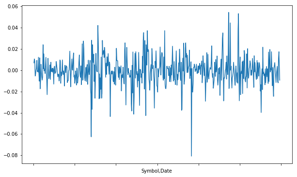

```python
import sys
format = lambda x: float('%.2f' % x)
returns['High'].plot()
```

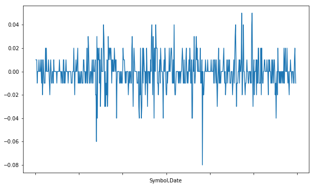

```python
formatted_returns = returns.High.map(format)
formatted_returns.plot()
```

```python
formatted_returns.to_csv(sys.stdout, sep=',')
```

```
F,2015-02-09,
F,2015-02-10,0.01
F,2015-02-11,0.01
F,2015-02-12,0.01
F,2015-02-13,-0.01
F,2015-02-16,-0.0
F,2015-02-17,0.0
F,2015-02-18,0.0
F,2015-02-19,0.01
F,2015-02-20,-0.0
F,2015-02-23,-0.0
F,2015-02-24,-0.0
F,2015-02-25,0.01
F,2015-02-26,-0.0
F,2015-02-27,-0.01
F,2015-03-02,0.01
F,2015-03-03,-0.02
F,2015-03-04,-0.01
F,2015-03-05,0.01
F,2015-03-06,-0.0
F,2015-03-09,-0.01
F,2015-03-10,-0.01
F,2015-03-11,-0.01
F,2015-03-12,0.02
F,2015-03-13,0.0
F,2015-03-16,0.02
F,2015-03-17,-0.0
F,2015-03-18,0.0
F,2015-03-19,-0.0
F,2015-03-20,0.0
F,2015-03-23,0.01
F,2015-03-24,-0.0
F,2015-03-25,-0.01
F,2015-03-26,-0.02
F,2015-03-27,-0.0
F,2015-03-30,0.01
F,2015-03-31,0.0
F,2015-04-01,-0.01
F,2015-04-02,-0.01
F,2015-04-03,-0.0
```

[output cut: 543 more lines]

```
F,2017-05-04,0.0
F,2017-05-05,0.0
F,2017-05-08,0.01
F,2017-05-09,0.0
F,2017-05-10,-0.0
F,2017-05-11,-0.01
F,2017-05-12,-0.0
F,2017-05-15,0.0
F,2017-05-16,0.0
F,2017-05-17,-0.01
F,2017-05-18,-0.01
F,2017-05-19,0.01
F,2017-05-22,0.02
F,2017-05-23,0.0
F,2017-05-24,-0.01
```

```python
formatted_returns.to_csv('ch06/morningstar_high.csv', sep=',')
```

```python
!type ch06\\morningstar_high.csv
```

```
F,2015-02-09,
F,2015-02-10,0.01
F,2015-02-11,0.01
F,2015-02-12,0.01
F,2015-02-13,-0.01
F,2015-02-16,-0.0
F,2015-02-17,0.0
F,2015-02-18,0.0
F,2015-02-19,0.01
F,2015-02-20,-0.0
F,2015-02-23,-0.0
F,2015-02-24,-0.0
F,2015-02-25,0.01
F,2015-02-26,-0.0
F,2015-02-27,-0.01
F,2015-03-02,0.01
F,2015-03-03,-0.02
F,2015-03-04,-0.01
F,2015-03-05,0.01
F,2015-03-06,-0.0
F,2015-03-09,-0.01
F,2015-03-10,-0.01
F,2015-03-11,-0.01
F,2015-03-12,0.02
F,2015-03-13,0.0
F,2015-03-16,0.02
F,2015-03-17,-0.0
F,2015-03-18,0.0
F,2015-03-19,-0.0
F,2015-03-20,0.0
F,2015-03-23,0.01
F,2015-03-24,-0.0
F,2015-03-25,-0.01
F,2015-03-26,-0.02
F,2015-03-27,-0.0
F,2015-03-30,0.01
F,2015-03-31,0.0
F,2015-04-01,-0.01
F,2015-04-02,-0.01
F,2015-04-03,-0.0
```

[output cut: 543 more lines]

```
F,2017-05-04,0.0
F,2017-05-05,0.0
F,2017-05-08,0.01
F,2017-05-09,0.0
F,2017-05-10,-0.0
F,2017-05-11,-0.01
F,2017-05-12,-0.0
F,2017-05-15,0.0
F,2017-05-16,0.0
F,2017-05-17,-0.01
F,2017-05-18,-0.01
F,2017-05-19,0.01
F,2017-05-22,0.02
F,2017-05-23,0.0
F,2017-05-24,-0.01
```

```python
%matplotlib inline
```

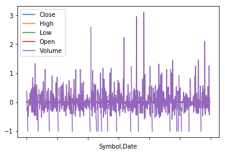

```python
returns.plot()
```

### **유일 값, 값 세기, 멤버십**

1차원 Series에 담긴 값의 정보를 추출하는 메소드

```python
obj = Series(['c', 'a', 'd', 'a', 'a', 'b', 'b', 'c', 'c'])
```

```python
display(obj)
obj.unique()
```

```
0    c
1    a
2    d
3    a
4    a
5    b
6    b
7    c
8    c
dtype: object
```

```
array(['c', 'a', 'd', 'b'], dtype=object)
```

value_counts 메소드는 obj에서 도수를 계산하여 반환

```python
display(obj); obj.value_counts()
```

```
0    c
1    a
2    d
3    a
4    a
5    b
6    b
7    c
8    c
dtype: object
```

```
a    3
c    3
b    2
d    1
dtype: int64
```

value_counts 메소드는 pandas 모듈에도 있으므로 아래와 같이 사용 가능

```python
pd.value_counts(obj.values, sort=False)
```

```
b    2
c    3
a    3
d    1
dtype: int64
```

isin 메소드는 어떤 값이 Series에 있는지 나타내는 불리언 벡터를 반환, Series나 DataFrame의 칼럼에서 값을 골라내고 싶을 때 유용

```python
display(obj)
mask = obj.isin(['b', 'c'])
display(mask)
obj[mask]
```

```
0    c
1    a
2    d
3    a
4    a
5    b
6    b
7    c
8    c
dtype: object
```

```
0     True
1    False
2    False
3    False
4    False
5     True
6     True
7     True
8     True
dtype: bool
```

```
0    c
5    b
6    b
7    c
8    c
dtype: object
```

value_counts 메소드와 apply를 이용하면 여러 행에 대한 히스토그램을 구할 수 있다. 누락 값은 fillna 함수를 이용해 처리한다.

```python
data = DataFrame({'Qu1': [1, 3, 4, 3, 4],
                  'Qu2': [2, 3, 1, 2, 3],
                  'Qu3': [1, 5, 2, 4, 4]})
```

```python
display(data)
result = data.apply(pd.value_counts).fillna(0)
result
```

|  | Qu1 | Qu2 | Qu3 |
| --- | --- | --- | --- |
| 0 | 1 | 2 | 1 |
| 1 | 3 | 3 | 5 |
| 2 | 4 | 1 | 2 |
| 3 | 3 | 2 | 4 |
| 4 | 4 | 3 | 4 |

|  | Qu1 | Qu2 | Qu3 |
| --- | --- | --- | --- |
| 1 | 1.0 | 1.0 | 1.0 |
| 2 | 0.0 | 2.0 | 1.0 |
| 3 | 2.0 | 2.0 | 0.0 |
| 4 | 2.0 | 0.0 | 2.0 |
| 5 | 0.0 | 0.0 | 1.0 |